# Limite Credito por Idade e Região

Marcio Cruz

28/06/2021

## Case

Uma instituição financeira tem o objetivo de estimar o valor de Limite de Cheque Especial para seus novos clientes, com base em informações disponíveis em seu banco de dados. Para o estudo, foi disponibilizada uma amostra histórica de clientes com as informações de Idade, Rendimento Total, Salário, Limite de Crédito Imediato, Escolaridade, Gênero e Região para investigar se é possível estimar o Limite do Cheque Especial. Avalie a possibilidade de fornecer uma “regra” por meio de um modelo estatístico, interprete como as informações predizem o evento de interesse e qual a performance desta “regra”.

## Respostas

### a) Faça o gráfico de dispersão entre as variáveis.

```
## [1] "Idade"                   "RendimentoTotal"
## [3] "Salario"                 "LimitedeCreditoImediato"
## [5] "LimitedoChequeEspecial"  "Escolaridade"
## [7] "Região"                  "Gênero"
```

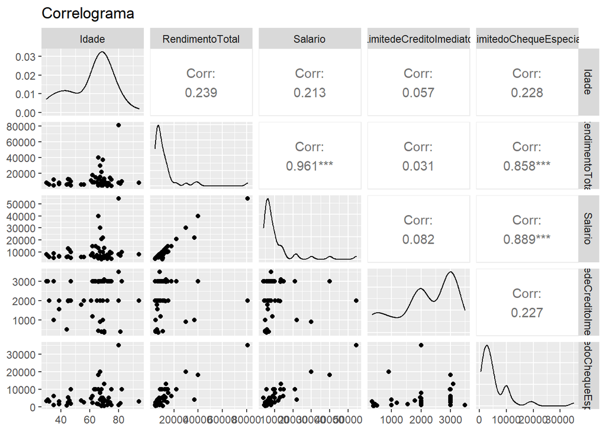

### b) Calcule o coeficiente de correlação entre as variáveis quantitativas. Interprete os coeficientes.

**Interpretação:** Os coeficientes estão no item “a”. As variáveis de Salário e e Rendimento TOtal possuem multicolinearidade entre si. Assim, adotou-se avariável com a maior correlação que é salário.

### c) Obtenha o modelo de regressão linear múltipla e faça a seleção de variáveis pelo método Backward

```r
regressao1 <- lm(data = dados_lim_cred, formula = LimitedoChequeEspecial ~ Idade + Salario + LimitedeCreditoImediato + Escolaridade + Região + Gênero)
summary(regressao1)
```

```
##
## Call:
## lm(formula = LimitedoChequeEspecial ~ Idade + Salario + LimitedeCreditoImediato +
##     Escolaridade + Região + Gênero, data = dados_lim_cred)
##
## Residuals:
##     Min      1Q  Median      3Q     Max
## -7286.7  -920.9   -49.4  1089.5  5879.1
##
## Coefficients:
##                             Estimate  Std. Error t value          Pr(>|t|)
## (Intercept)              -2502.23770  1554.31067  -1.610           0.11510
## Idade                        0.30764    22.52838   0.014           0.98917
## Salario                      0.46010     0.04357  10.560 0.000000000000289 ***
## LimitedeCreditoImediato      0.14191     0.41092   0.345           0.73160
## EscolaridadeSuperior_Pos   536.13487   956.58697   0.560           0.57821
## RegiãoSP                  2199.67324   785.62262   2.800           0.00776 **
## GêneroM                   3503.72844  1050.30006   3.336           0.00181 **
## ---
## Signif. codes:  0 '***' 0.001 '**' 0.01 '*' 0.05 '.' 0.1 ' ' 1
##
## Residual standard error: 2271 on 41 degrees of freedom
## Multiple R-squared:  0.8804, Adjusted R-squared:  0.8629
## F-statistic:  50.3 on 6 and 41 DF,  p-value: < 0.00000000000000022
```

```r
regressao2 <- lm(data = dados_lim_cred, formula = LimitedoChequeEspecial ~ Salario + LimitedeCreditoImediato + Escolaridade + Região + Gênero)
summary(regressao2)
```

```
##
## Call:
## lm(formula = LimitedoChequeEspecial ~ Salario + LimitedeCreditoImediato +
##     Escolaridade + Região + Gênero, data = dados_lim_cred)
##
## Residuals:
##     Min      1Q  Median      3Q     Max
## -7285.0  -917.0   -56.8  1085.9  5880.5
##
## Coefficients:
##                             Estimate  Std. Error t value          Pr(>|t|)
## (Intercept)              -2485.26276   921.94395  -2.696           0.01006 *
## Salario                      0.46016     0.04278  10.757 0.000000000000122 ***
## LimitedeCreditoImediato      0.14191     0.40600   0.350           0.72844
## EscolaridadeSuperior_Pos   535.89763   944.97669   0.567           0.57366
## RegiãoSP                  2201.43537   765.67351   2.875           0.00631 **
## GêneroM                   3504.77037  1034.98169   3.386           0.00155 **
## ---
## Signif. codes:  0 '***' 0.001 '**' 0.01 '*' 0.05 '.' 0.1 ' ' 1
##
## Residual standard error: 2243 on 42 degrees of freedom
## Multiple R-squared:  0.8804, Adjusted R-squared:  0.8662
## F-statistic: 61.83 on 5 and 42 DF,  p-value: < 0.00000000000000022
```

```r
regressao3 <- lm(data = dados_lim_cred, formula = LimitedoChequeEspecial ~ Salario + Escolaridade + Região + Gênero)
summary(regressao3)
```

```
##
## Call:
## lm(formula = LimitedoChequeEspecial ~ Salario + Escolaridade +
##     Região + Gênero, data = dados_lim_cred)
##
## Residuals:
##    Min     1Q Median     3Q    Max
##  -7488  -1012    -18   1232   5881
##
## Coefficients:
##                             Estimate  Std. Error t value           Pr(>|t|)
## (Intercept)              -2243.28128   602.59435  -3.723           0.000568 ***
## Salario                      0.45742     0.04162  10.990 0.0000000000000456 ***
## EscolaridadeSuperior_Pos   518.91434   934.04407   0.556           0.581393
## RegiãoSP                  2245.40290   747.52077   3.004           0.004432 **
## GêneroM                   3668.18009   913.89830   4.014           0.000235 ***
## ---
## Signif. codes:  0 '***' 0.001 '**' 0.01 '*' 0.05 '.' 0.1 ' ' 1
##
## Residual standard error: 2220 on 43 degrees of freedom
## Multiple R-squared:   0.88,  Adjusted R-squared:  0.8689
## F-statistic: 78.87 on 4 and 43 DF,  p-value: < 0.00000000000000022
```

```r
regressao4 <- lm(data = dados_lim_cred, formula = LimitedoChequeEspecial ~ Salario + Região + Gênero)
summary(regressao4)
```

```
##
## Call:
## lm(formula = LimitedoChequeEspecial ~ Salario + Região + Gênero,
##     data = dados_lim_cred)
##
## Residuals:
##     Min      1Q  Median      3Q     Max
## -7809.4  -830.6     9.0  1289.6  5792.4
##
## Coefficients:
##                Estimate  Std. Error t value           Pr(>|t|)
## (Intercept) -2309.11531   586.16765  -3.939           0.000288 ***
## Salario         0.46161     0.04061  11.367 0.0000000000000111 ***
## RegiãoSP     2395.81108   691.27559   3.466           0.001192 **
## GêneroM      3963.11176   738.02823   5.370 0.0000028181198919 ***
## ---
## Signif. codes:  0 '***' 0.001 '**' 0.01 '*' 0.05 '.' 0.1 ' ' 1
##
## Residual standard error: 2203 on 44 degrees of freedom
## Multiple R-squared:  0.8792, Adjusted R-squared:  0.871
## F-statistic: 106.7 on 3 and 44 DF,  p-value: < 0.00000000000000022
```

### d) Interprete os parâmetros do modelo e o coeficiente de determinação

**Interpretação:** Feito a comparação entre as várias variáveis do modelo e, definiu que iria ser utilizado as variáveis Salário, Região e Gênero, já que apresentaram uma melhor resposta ao limite de crédito, com explicação de 87,10%.

### e) Apresente a equação do modelo estimado

y_estimado <- -2309.11531 + (0.46161 x salario) + (2395.81108 x regiao) + (3963.11176 x genero)

### f) Estime o valor do limite de cheque especial para um cliente que tem salário de R$4.850, de São Paulo e gênero masculino.

```r
x.salario <- 4850
x.regiao <- 1 # SP
x.genero <- 1 # Masculino
y_estimado <- -2309.11531 + (0.46161 * x.salario) + (2395.81108 * x.regiao) + (3963.11176 * x.genero)
```

O valor estimado do limite do cheque especial é R$ 6288.62